# Data Summary Exercise

Yuanting Lu

09/09/2026

### EV Dataset

#### Load Dataset

We will work with the ev dataset, a subset of all registered electric vehicals (EV) in the state of Washington in late 2023. Copy and paste the following command to load the dataset into R.

```r
ev <- read.csv('https://albums.yuanting.lu/sta126/data/ev.csv')
```

#### Preview

1. How many vehicles are in the dataset?
2. How many variables are in the dataset? Are they quantitative or qualitative?

#### Qualitative Variable

1. How many different manufacturers are in the dataset?
2. How many different models of EV are in the dataset?
3. What is the proportion of Model Beta in the dataset?
4. Draw a bargraph to visually compare the proportion of different models. Clearly label the title, the x- and y-axis labels.

#### Quantitative Variable

1. The `Range` column records the miles that an EV can travel after a full charge. Find the mean and the median of the driving distance.
2. Find the five-number summary.
3. Draw a boxplot. Do you see any outliers? Use calculations to explain your observation.
4. Find the range of miles that contains the middle 50% of EVs.
5. At least how many miles can the top 10% of the EVs travel after a full charge?
6. Draw a histogram for the `Range` variable. Describe the shape of the distribution.
7. Estimate the standard deviation of the travel distance. Then check your estimate by calculating the standard deviation.
8. Based on the boxplots below, which model is most consistent in terms of travel distance after a full charge?

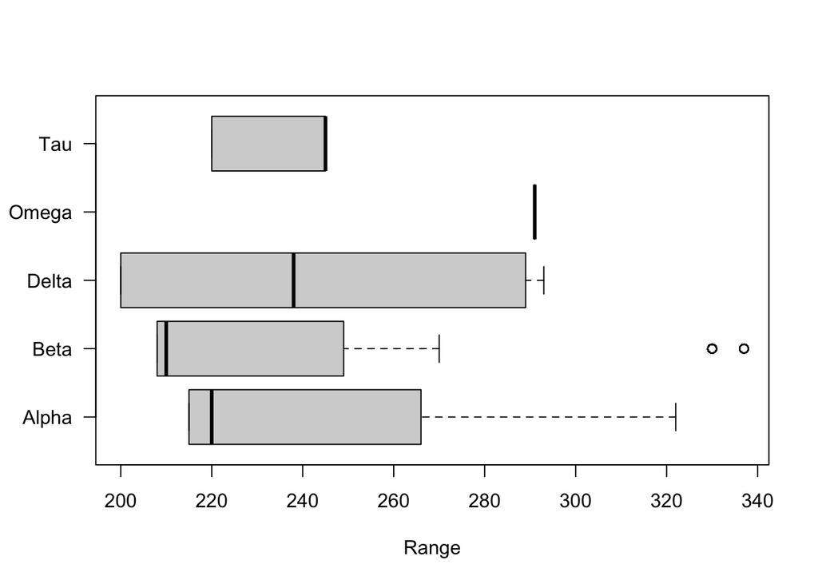

   ```r
   boxplot(Range ~ Model, data = ev, horizontal = TRUE, las = 1, ylab = '')
   ```

9. The tables below shows the means and the standard deviations of range for each model. Which car has a better relative range: a Model Alpha with a range of 260 miles or a Model Beta with a range of 260 miles? Explain your answer using the $z$-scores.

   ```
   ## Means:
   ```

   ```
   ##    Alpha     Beta    Delta    Omega      Tau
   ## 238.4779 228.5192 241.9596 291.0000 235.2439
   ```

   ```
   ## Standard deviations:
   ```

   ```
   ##    Alpha     Beta    Delta    Omega      Tau
   ## 38.44676 34.93285 38.74377  0.00000 12.34662
   ```

### College Dataset

The College dataset contains information about 777 U.S. colleges and universities based on data from the 1995 issue of U.S. News & World Report.[^1]

```r
College <- read.csv('https://albums.yuanting.lu/sta126/data/ISLR-College.csv')
names(College)
```

```
##  [1] "Private"     "Apps"        "Accept"      "Enroll"      "Top10perc"
##  [6] "Top25perc"   "F.Undergrad" "P.Undergrad" "Outstate"    "Room.Board"
## [11] "Books"       "Personal"    "PhD"         "Terminal"    "S.F.Ratio"
## [16] "perc.alumni" "Expend"      "Grad.Rate"
```

```
## _U._S. _N_e_w_s _a_n_d _W_o_r_l_d _R_e_p_o_r_t'_s _C_o_l_l_e_g_e _D_a_t_a
##
## _D_e_s_c_r_i_p_t_i_o_n:
##
##      Statistics for a large number of US Colleges from the 1995 issue
##      of US News and World Report.
##
## _U_s_a_g_e:
##
##      College
##
## _F_o_r_m_a_t:
##
##      A data frame with 777 observations on the following 18 variables.
##
##      'Private' A factor with levels 'No' and 'Yes' indicating private
##           or public university
##
##      'Apps' Number of applications received
##
##      'Accept' Number of applications accepted
##
##      'Enroll' Number of new students enrolled
##
##      'Top10perc' Pct. new students from top 10% of H.S. class
##
##      'Top25perc' Pct. new students from top 25% of H.S. class
##
##      'F.Undergrad' Number of fulltime undergraduates
##
##      'P.Undergrad' Number of parttime undergraduates
##
##      'Outstate' Out-of-state tuition
##
##      'Room.Board' Room and board costs
##
##      'Books' Estimated book costs
##
##      'Personal' Estimated personal spending
##
```

[output cut: 15 more lines]

```
##      maintained at Carnegie Mellon University. The dataset was used in
##      the ASA Statistical Graphics Section's 1995 Data Analysis
##      Exposition.
##
## _R_e_f_e_r_e_n_c_e_s:
##
##      James, G., Witten, D., Hastie, T., and Tibshirani, R. (2013) _An
##      Introduction to Statistical Learning with applications in R_,
##      <https://www.statlearning.com>, Springer-Verlag, New York
##
## _E_x_a_m_p_l_e_s:
##
##      summary(College)
##      lm(Apps~Private+Accept,data=College)
##
```

Answer the following questions:

1. What is the percentage of private schools in the dataset?
2. What is the smallest and largest student/faculty ratio?
3. Our University’s student-to-faculty ratio is 11:1. How does that compare with the other institutions in this dataset?
4. The boxplot compares the out of state tuition between private and public schools. Which one has a larger standard deviation?

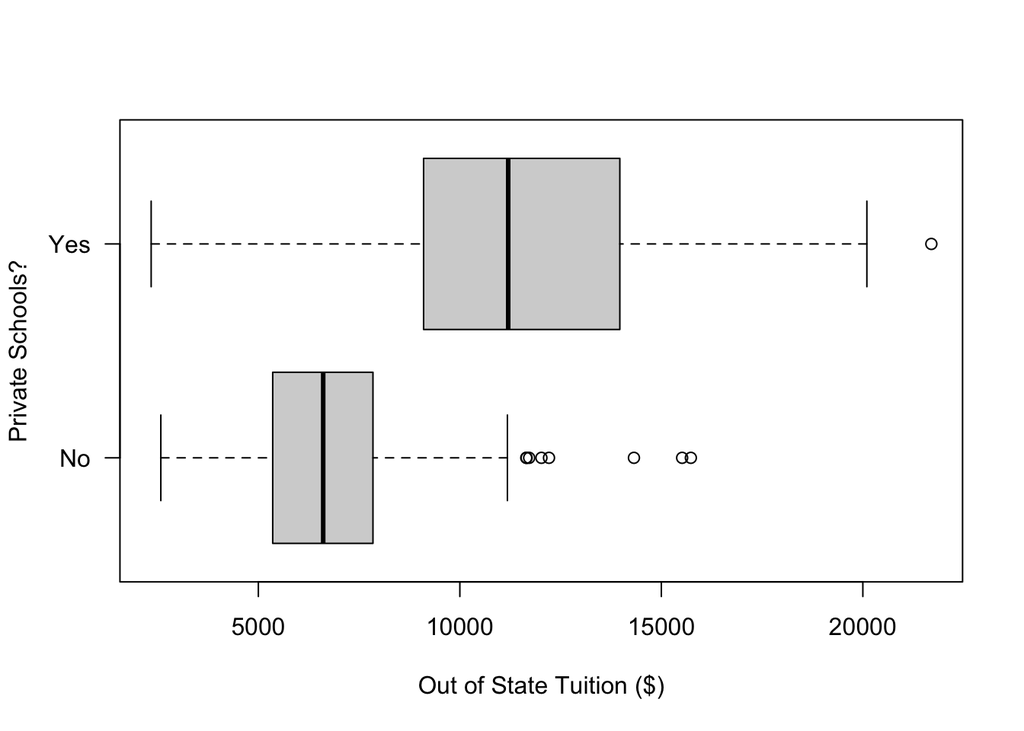

5. Match the boxplots with the histograms. Which one shows the graduation distribution of the private schools in the dataset?

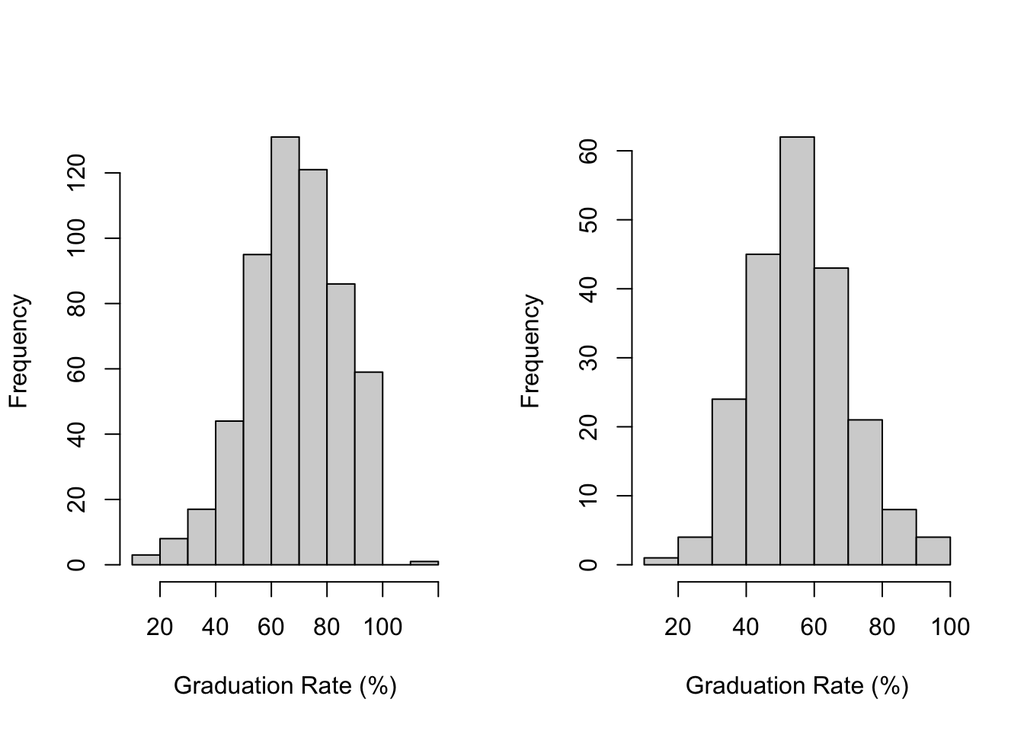

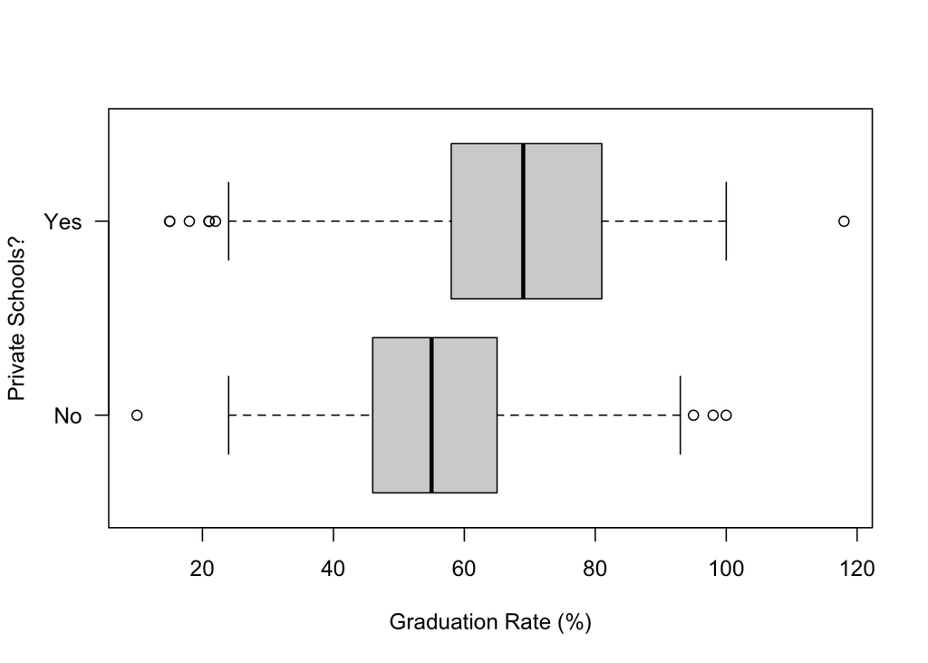

### [Plus]Dataset Filter Skills

1. Downloaded the raw dataset as a .csv file from [data.gov](https://catalog.data.gov/dataset/electric-vehicle-population-data?from_hint=eyJzb3J0IjoicG9wdWxhcml0eSJ9). It is most likely saved as export.csv in your Download folder.
2. Load the raw dataset from your Download folder. Be sure to replace the “Your-user-name” in the command line with your actually username on your laptop.
   - Mac version:

   ```r
   raw <- read.csv("/Users/Your-user-name/Downloads/export.csv", header = TRUE)
   ```

   - Windows version:

   ```r
   raw <- read.csv("C:/Users/Your-user-name/Downloads/export.csv", header = TRUE)
   ```

3. Extract a particular car maker with meaningful range values from the large raw file.

   ```r
   tesla <- subset(raw, Make == "TESLA" & Electric.Range > 50)
   ```

4. Select columns.

   ```r
   ev <- tesla[,c("VIN..1.10.","County", "City", "Model.Year", "Make","Model","Electric.Range")]
   ```

5. Rename the selected columns.

   ```r
   names(ev) <- c("VIN", "County", "City", "Year", "Make", "Model", "Range")
   ```

6. De-identify values.

   ```r
   ev$Make[ev$Make == "TESLA"] <- "WallE"
   ev$Model <- factor(ev$Model,
                  levels = c("MODEL 3", "MODEL S", "MODEL X", "MODEL Y", "ROADSTER"),
                  labels = c("Alpha", "Beta", "Delta", "Omega", "Tau"))
   ```

7. Save the filtered dataset to a file.
   - Mac version:

   ```r
   write.csv("/Users/Your-user-name/Downloads/ev.csv", header = TRUE)
   ```

   - Windows version:

   ```r
   write.csv("C:/Users/Your-user-name/Downloads/ev.csv", header = TRUE)
   ```

[^1]: Gareth James, Daniela Witten, Trevor Hastie, Robert Tibshirani. (2013). *An introduction to statistical learning : with applications in R*. New York: Springer.